# Mathematical building blocks of neural networks

MACS 30200 University of Chicago

## First look at a neural network

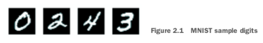

## Import data

```r
library(keras)

mnist <- dataset_mnist()
train_images <- mnist$train$x
train_labels <- mnist$train$y
test_images <- mnist$test$x
test_labels <- mnist$test$y
```

## Structure of data

```r
str(train_images)
```

```
##  int [1:60000, 1:28, 1:28] 0 0 0 0 0 0 0 0 0 0 ...
```

```r
str(train_labels)
```

```
##  int [1:60000(1d)] 5 0 4 1 9 2 1 3 1 4 ...
```

```r
str(test_images)
```

```
##  int [1:10000, 1:28, 1:28] 0 0 0 0 0 0 0 0 0 0 ...
```

```r
str(test_labels)
```

```
##  int [1:10000(1d)] 7 2 1 0 4 1 4 9 5 9 ...
```

## Build the network

```r
network <- keras_model_sequential() %>%
  layer_dense(units = 512, activation = "relu", input_shape = c(28 * 28)) %>%
  layer_dense(units = 10, activation = "softmax")
```

## Compile the network

```r
network %>% compile(
  optimizer = "rmsprop",
  loss = "categorical_crossentropy",
  metrics = c("accuracy")
)
```

## Reshape the data

```r
train_images <- array_reshape(train_images, c(60000, 28 * 28))
train_images <- train_images / 255

test_images <- array_reshape(test_images, c(10000, 28 * 28))
test_images <- test_images / 255
```

```r
train_labels <- to_categorical(train_labels)
test_labels <- to_categorical(test_labels)
```

## Train the network

```r
network %>%
  fit(train_images, train_labels, epochs = 5, batch_size = 128)
```

## Assess the model

```r
metrics <- network %>% evaluate(test_images, test_labels, verbose = 0)
metrics
```

```
## $loss
## [1] 2.272155
##
## $acc
## [1] 0.1682
```

## Data representations for neural networks

- Tensor
- Generalization of vectors and matricies to higher-dimensions

## Scalars (0D tensors)

- A tensor containing a single number
- Python - Numpy `float32` or `float64` number
- R - vector of length 1

## Vectors (1D tensors)

- A tensor with a one-dimensional array of numbers
- Has exactly one axis
- Python - Numpy vector
- R - vector

## Vectors (1D tensors)

```r
x <- c(12, 3, 6, 14, 10)
str(x)
```

```
##  num [1:5] 12 3 6 14 10
```

```r
dim(as.array(x))
```

```
## [1] 5
```

- 5D vector $\neq$ 5D tensor

## Matricies (2D tensors)

- A tensor with a two-dimensional array of numbers
- Two axes (frequently rows and columns)
- Visually is a rectangular grid of numbers
- Python - Numpy matrix
- R - matrix

## Matricies (2D tensors)

```r
x <- matrix(rep(0, 3*5), nrow = 3, ncol = 5)
x
```

```
##      [,1] [,2] [,3] [,4] [,5]
## [1,]    0    0    0    0    0
## [2,]    0    0    0    0    0
## [3,]    0    0    0    0    0
```

```r
dim(x)
```

```
## [1] 3 5
```

## 3D tensors and higher-dimensional tensors

- Array of matricies
- Python - Numpy 3D tensor
- R - array

## 3D tensors and higher-dimensional tensors

```r
x <- array(rep(0, 2*3*2), dim = c(2, 3, 2))
x
```

```
## , , 1
##
##      [,1] [,2] [,3]
## [1,]    0    0    0
## [2,]    0    0    0
##
## , , 2
##
##      [,1] [,2] [,3]
## [1,]    0    0    0
## [2,]    0    0    0
```

```r
str(x)
```

```
##  num [1:2, 1:3, 1:2] 0 0 0 0 0 0 0 0 0 0 ...
```

```r
dim(x)
```

```
## [1] 2 3 2
```

## Key attributes

- Number of axes (rank)
- Shape
  - Matrix example - $(3,5)$
  - 3D tensor example - $(2,3,2)$
- Data type

## Data batches

- Samples axis
- Batching and batch axis

## Vector data

- 2D tensors of shape (`samples`, `features`)
- Each data point is encoded as a vector

## Actuarial dataset of people

- Age
- ZIP code
- Income
- Person - vector of 3 values
- Dataset - 100,000 individuals
- 2D tensor of shape `(100000, 3)`

## Text documents

- Each document has a count of the frequency each word appears in it
- Dictionary of 20,000 words
- Document - vector of 20,000 values
- Documents - 500 documents
- 2D tensor of shape `(500, 20000)`

## Time series data

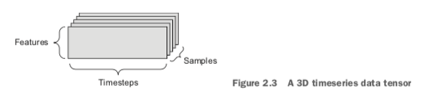

## Stock prices

- Current price of a stock
- Highest price in the past minute
- Lowest price in the past minute
- Recorded every minute for a single stock
- Day of trading - 2D tensor of shape `(390, 3)`
- 250 days’ worth of data - 3D tensor of shape `(250, 390, 3)`

## Image data

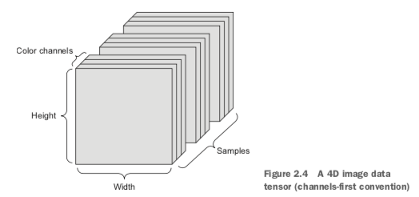

## Video data

- Requires 5D tensor
- Each frame is a color image (`height`, `width`, `color_depth`)
- Sample of frames for a single video (`frames`, `height`, `width`, `color_depth`)
- Batch of videos (`samples`, `frames`, `height`, `width`, `color_depth`)

## Tensor operations

- Generalizations of matrix operations
  - Addition
  - Subtraction
  - Multiplication
- If you can do it with a matrix, you can do it with a tensor

## Geometric interpretation

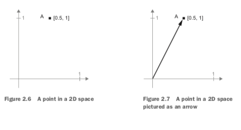

## Geometric interpretation

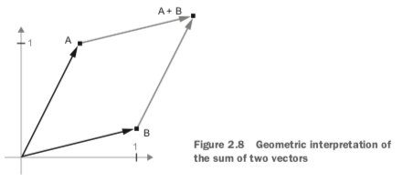

## Geometric interpretation of deep learning

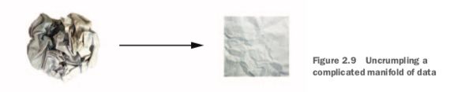

## Gradient-based optimization

```
output = relu(dot(W, input) + B)
```

- `input`
- `dot()`
- `relu()`
- `W, b`
- Adjust the weights to produce the lowest loss score
- Initialize the weights with random values that are not useful

## Training loop

1. Draw a batch of training samples `x` and targets `y`
2. Forward pass - run the network on `x` to obtain predictions `y_pred`
3. Compute the loss of the network on the batch (mismatch between `y_pred` and `y`)
4. Update the weights of the network in a way that slightly reduces the loss on this batch

## Naive solution

- Freeze all weights except one scalar coefficient and try different values for that coefficient
- Horribly inefficient
- Use differentiation and compute the **gradient** of the loss with regard to the network’s coefficients
- Move the coefficients in the opposite direction from the gradient, thus decreasing the loss

## Derivative

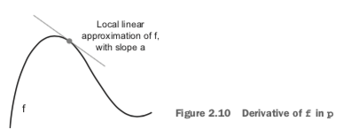

## Derivative of a tensor operation

```
y_pred = dot(W, x)
loss_value = loss(y_pred, y)
```

```
loss_value = f(W)
```

```
loss_value = f(W0)
f'(W0)
```

## Stochastic gradient descent

1. Draw a batch of training samples `x` and targets `y`
2. Forward pass - run the network on `x` to obtain predictions `y_pred`
3. Compute the loss of the network on the batch (mismatch between `y_pred` and `y`)
4. Backward pass - compute the gradient of the loss with regard to the network’s parameters
5. Move the parameters a little in the opposite direction from the gradient to reduce the loss for the batch

## Stochastic gradient descent

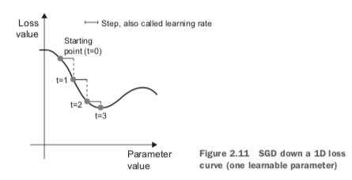

## Stochastic gradient descent

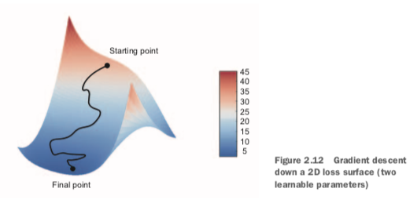

## Momentum

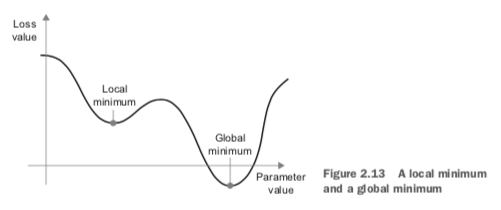

## Backpropogation

- Chained tensor operations

  ```
  f(W1, W2, W3) = a(W1, b(W2, c(W3)))
  ```

- Calculus and the chain rule

  ```
  f(g(x)) = f'(g(x)) * g'(x)
  ```

- Backpropogation
  - Start with the final loss value
  - Work backwards from the top layers to the bottom layers
  - Apply the chain rule to compute the contribution that each parameter had in the loss value

## Import our data

```r
library(keras)

mnist <- dataset_mnist()
train_images <- mnist$train$x
train_labels <- mnist$train$y
test_images <- mnist$test$x
test_labels <- mnist$test$y
```

## The network

```r
network <- keras_model_sequential() %>%
  layer_dense(units = 512, activation = "relu", input_shape = c(28 * 28)) %>%
  layer_dense(units = 10, activation = "softmax")
```

## Compilation

```r
network %>% compile(
  optimizer = "rmsprop",
  loss = "categorical_crossentropy",
  metrics = c("accuracy")
)
```

## Training loop

```r
network %>%
  fit(train_images, train_labels, epochs = 5, batch_size = 128)
```